# EDA_full

```python
from lxml import etree
import matplotlib.pyplot as plt
import numpy as np
import imagesize
```

## Overall Number of Images Summary

```python
from os import walk

# Parse image directories
datadir = "./cubicasa5k/"
categories = ["colorful", "high_quality", "high_quality_architectural"]
image_dirs = {cat: None for cat in categories} # list of dir names in each category
for cat in categories:
    path = datadir + cat
    for _, dirnames, _ in walk(path):
        image_dirs[cat] = dirnames
        break
```

```python
print("Number of floor plans in each category:")
for cat in categories:
    print(f"{cat}: {len(image_dirs[cat])}")
```

```
Number of floor plans in each category:
colorful: 276
high_quality: 992
high_quality_architectural: 3732
```

## Sample Images

[figure not shown]

[figure not shown]

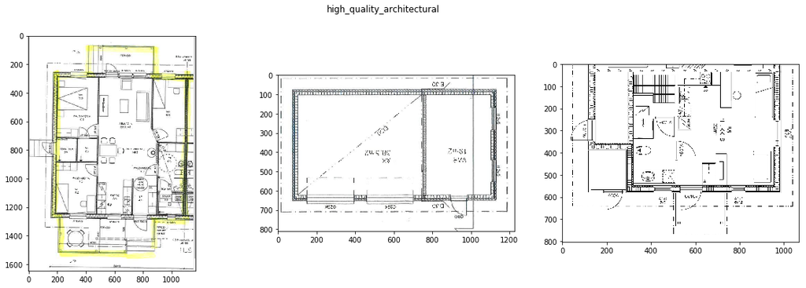

```python
for cat in categories:
    fig, axes = plt.subplots(nrows=1, ncols=3, figsize=(20, 6))
    fig.suptitle(cat)
    choices = np.random.choice(image_dirs[cat], size=3)
    for i, choice in enumerate(choices):
        fpath = datadir + cat + "/" + choice + "/F1_scaled.png"
        axes[i].imshow(plt.imread(fpath))
```

## Image Dimension Analysis

```python
def plot_hist(ax, data,xlabel, bins, range_=None, title=None):
    """Helper function for plotting histogram
    """
    ax.hist(data, bins=bins, range=range_)
    ax.set_xlabel(xlabel)
    ax.set_ylabel("counts")
    ax.set_title(title)
```

```python
# Get image sizes
original_sizes = {cat: [] for cat in categories}
scaled_sizes = {cat: [] for cat in categories}

for cat, dirs in image_dirs.items():
    # Read original and scaled image sizes
    for dir_ in dirs:
        orig_fpath = datadir + cat + "/" + dir_ + "/F1_original.png"
        orig_shape = imagesize.get(orig_fpath)
        original_sizes[cat].append((int(dir_), *orig_shape))

        scaled_fpath = datadir + cat + "/" + dir_ + "/F1_scaled.png"
        scaled_shape = imagesize.get(scaled_fpath)
        scaled_sizes[cat].append((int(dir_), *scaled_shape))

    # Store as numpy array
    original_sizes[cat] = np.array(original_sizes[cat])
    scaled_sizes[cat] = np.array(scaled_sizes[cat])
```

#### Aspect Ratio

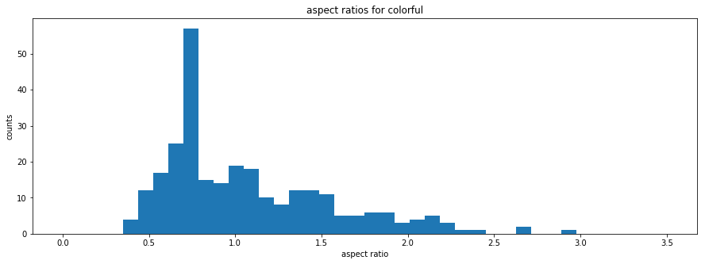

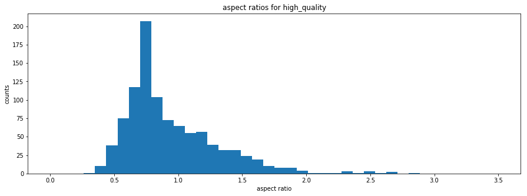

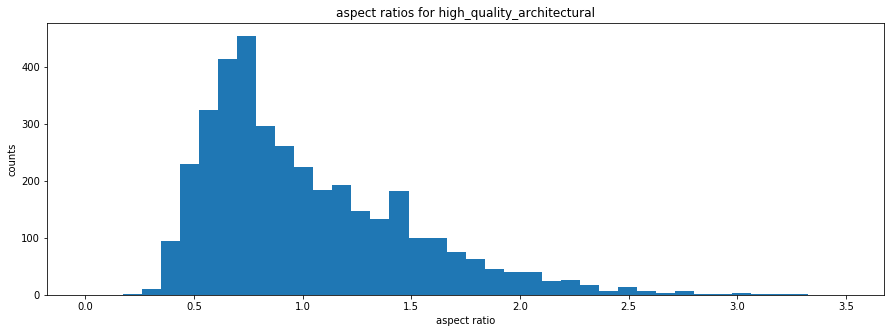

```python
# Plot aspect ratios histograms
for cat in categories:
    # Get aspect ratios
    original_aspects = original_sizes[cat][:, 2] / original_sizes[cat][:, 1]
    scaled_aspects = scaled_sizes[cat][:, 2] / scaled_sizes[cat][:, 1]
    assert np.allclose(original_aspects, scaled_aspects, atol=3e-3)

    # Plot histogram
    fig, ax = plt.subplots(nrows=1, ncols=1, figsize=(15, 5))
    plot_hist(ax, original_aspects, xlabel="aspect ratio", bins=40, range_=(0, 3.5), title=f"aspect ratios for {cat}")
```

Aspect ratios for each original image and the corresponding scaled image are the same.

The aspect ratios of the images vary a lot within a category. However, the distributions of the aspect ratios are fairly similar among the 3 categories.

#### Pixel Number

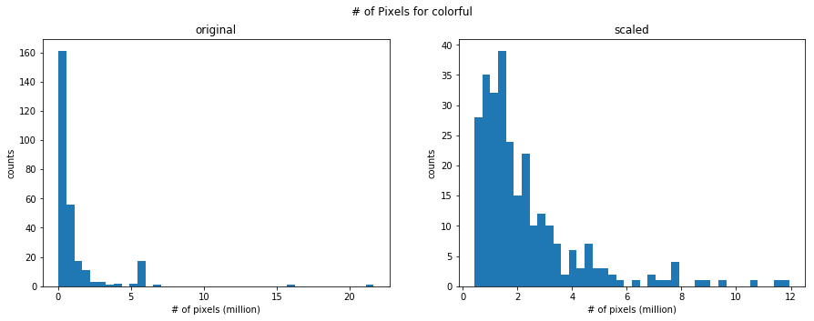

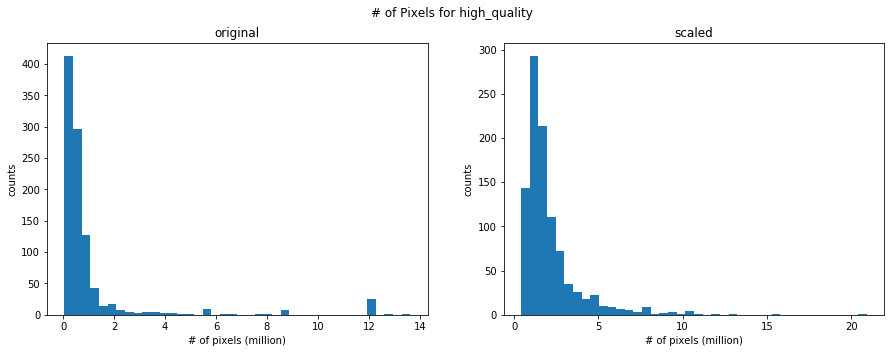

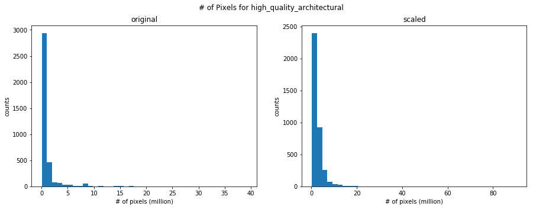

```python
# Plot pixel number histograms
for cat in categories:
    # Get aspect ratios
    original_pixels = original_sizes[cat][:, 2] * original_sizes[cat][:, 1] / 1e6
    scaled_pixels = scaled_sizes[cat][:, 2] * scaled_sizes[cat][:, 1] / 1e6
    assert np.allclose(original_aspects, scaled_aspects, atol=3e-3)

    # Plot histogram
    fig, axes = plt.subplots(nrows=1, ncols=2, figsize=(15, 5))
    fig.suptitle(f"# of Pixels for {cat}")
    plot_hist(axes[0], original_pixels, xlabel="# of pixels (million)", bins=40, title="original")
    plot_hist(axes[1], scaled_pixels, xlabel="# of pixels (million)", bins=40, title="scaled")
```

Compared to aspect ratios, the image sizes (i.e. numbers of pixels) are more similar across images. Scaled images, however, have wider distributions of image sizes than original images.

## 2. Exploration of model.svg

Since svg files contain key information about room structures, locations and specific labels for each room type, we use lxml to read in model.svg.

```python
Room_type={}
English2Finland={}
Numberofrooms={}
with open ('./cubicasa5k/train.txt') as f:
    for lines in f.read().splitlines():
        path='./cubicasa5k'+lines+'model.svg'
        tree = etree.parse(open(path, 'r'))
        Finland_word=[]
        for element in tree.iter():
             if element.tag.split("}")[1] == 'text':
                Finland_word.append(element.text)
        #english_check = re.compile(r'[A-Z]')
        position=0
        for element in tree.iter():
            if element.tag.split("}")[1] == 'g':
                if element.get("class") is not None and element.get("class")[:6]=='Space ':
                    room=element.get("class")[6:]

                    if room not in English2Finland:
                        English2Finland[room]=Finland_word[position*3]
                    position=position+1
                    if room in Room_type:
                        Room_type[room]=Room_type[room]+1
                    else:
                        Room_type[room]=1
        if position in Numberofrooms:
            Numberofrooms[position]=Numberofrooms[position]+1
        else:
            Numberofrooms[position]=1
```

Since the png files indicate room types in another language, we try to build a dictionary that translates it into English in order to better understand our data.

```python
print(English2Finland)
```

[output not shown]

Next, we try to count the frequency of each room types in our training data to get a better sense of what rooms are most common, and what rooms are rare. In the horizontal bar chart below, we can see that, besides 'undefined', bedroom, bathroom, outdoor and living room are most common room types among the 4200 floor maps. There are around 7000 bedrooms, 4000 bathrooms and outdoor area. Some extremely rare room types include bar, outdoor kitchen and bedroom guests, which all are non-essential when building a house.

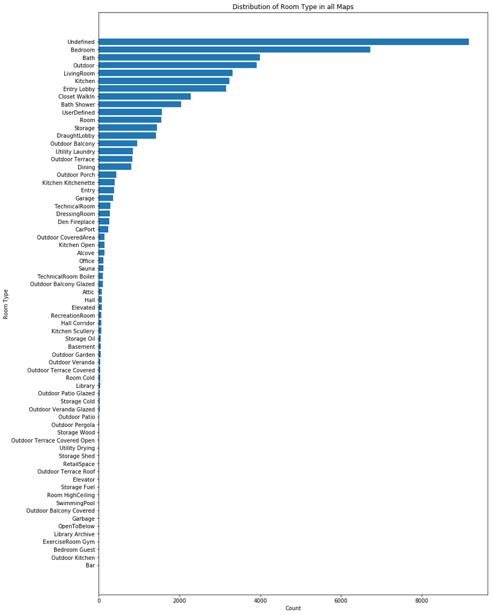

```python
room_list = list(Room_type.keys())
freq_list = np.array(list(Room_type.values()))
index = np.argsort(freq_list)
freq_list = sorted(freq_list)
new_room_list = [room_list[i] for i in index]
plt.figure(figsize=(13,20))
plt.barh(new_room_list, freq_list)
plt.xlabel('Count')
plt.ylabel('Room Type')
plt.title('Distribution of Room Type in all Maps')
```

To better understand the size/diversity of all the floor map, we want to examine how many rooms each floor map has. We created a bar chart to show the distribution. As we can see, Most of the floor maps has number of rooms range from 5 to 23, and a few maps have more than 40 rooms. Thus, we may conclude that most of the maps represent normal size houses, and a small portion of maps represent more luxurious floor arrangement.

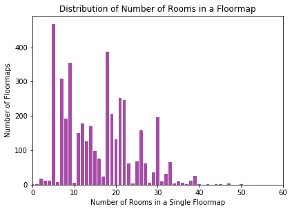

```python
num_room = list(Numberofrooms.keys())
num_room_index = np.argsort(np.array(num_room))
freq = list(Numberofrooms.values())
num_room_freq = [freq[i] for i in num_room_index]
plt.figure(figsize=(6.5,4.5))
plt.xlim(0,60)
plt.bar(num_room, num_room_freq, color = 'purple', alpha = 0.7)
plt.xlabel('Number of Rooms in a Single Floormap')
plt.ylabel('Number of Floormaps')
plt.title('Distribution of Number of Rooms in a Floormap')
```

## Some ideas about this project

After the exploratory analysis, we find out that the input dimension the floor maps varies a lot. In order to use technique like CNN or autoencoder, it is necessary to convert all images to a standard input dimension generate a standard format of the floor map. We have two ideas right now. The first one is to do image segmentation and build a network to identify all the room type labels and their corresponding position in an image. The other idea is to automatically generate a floor plan for input images. We may use technique like AE or VAE to identify specific arrangements and patterns contained in an input image.